# Overview

Dataset info

| Number of variables | 13 |
| --- | --- |
| Number of observations | 6497 |
| Missing cells | 0 (0.0%) |
| Duplicate rows | 1177 (18.1%) |
| Total size in memory | 660.0 KiB |
| Average record size in memory | 104.0 B |

Variables types

| Numeric | 12 |
| --- | --- |
| Categorical | 1 |
| Boolean | 0 |
| Date | 0 |
| URL | 0 |
| Text (Unique) | 0 |
| Rejected | 0 |
| Unsupported | 0 |

Warnings

| Dataset has 1177 (18.1%) duplicate rows | Warning |
| --- | --- |
| `citric_acid` has 151 (2.3%) zeros | Zeros |

# Variables

alcohol  
Numeric

| Distinct count | 91 |
| --- | --- |
| Unique (%) | 1.4% |
| Missing (%) | 0.0% |
| Missing (n) | 0 |
| Infinite (%) | 0.0% |
| Infinite (n) | 0 |

| Mean | 10.49154687 |
| --- | --- |
| Minimum | 8 |
| Maximum | 14.9 |
| Zeros (%) | 0.0% |

[figure not shown]

Toggle details

**Statistics**

Quantile statistics

| Minimum | 8 |
| --- | --- |
| 5-th percentile | 9 |
| Q1 | 9.5 |
| Median | 10.3 |
| Q3 | 11.3 |
| 95-th percentile | 12.7 |
| Maximum | 14.9 |
| Range | 6.9 |
| Interquartile range | 1.8 |

Descriptive statistics

| Standard deviation | 1.192534231 |
| --- | --- |
| Coef of variation | 0.1136661968 |
| Kurtosis | -0.5314804142 |
| Mean | 10.49154687 |
| MAD | 0.9964814885 |
| Skewness | 0.5658809362 |
| Sum | 68163.58 |
| Variance | 1.422137893 |
| Memory size | 50.9 KiB |

**Histogram**

[figure not shown]

**Histogram with fixed size bins** (bins=50)

[figure not shown]

**Histogram with variable size bins** (bins=[ 8. 8.45 8.65 8.95 9.025 ... 13.075 13.65 13.95 14.025 14.9 ], ["bayesian blocks"](https://ui.adsabs.harvard.edu/abs/2013ApJ...764..167S/abstract) binning strategy used)

**Common values**

| Value | Count | Frequency (%) |  |
| --- | --- | --- | --- |
| 9.5 | 367 | 5.6% |  |
| 9.4 | 332 | 5.1% |  |
| 9.2 | 271 | 4.2% |  |
| 10 | 232 | 3.6% |  |
| 10.5 | 229 | 3.5% |  |
| 11 | 219 | 3.4% |  |
| 9 | 215 | 3.3% |  |
| 9.8 | 214 | 3.3% |  |
| 10.4 | 196 | 3.0% |  |
| 9.3 | 193 | 3.0% |  |
| Other values (81) | 4029 | 62.0% |  |

**Extreme values**

Minimum 5 values

| Value | Count | Frequency (%) |  |
| --- | --- | --- | --- |
| 8 | 2 | < 0.1% |  |
| 8.4 | 5 | 0.1% |  |
| 8.5 | 10 | 0.2% |  |
| 8.6 | 23 | 0.4% |  |
| 8.7 | 80 | 1.2% |  |

Maximum 5 values

| Value | Count | Frequency (%) |  |
| --- | --- | --- | --- |
| 14.9 | 1 | < 0.1% |  |
| 14.2 | 1 | < 0.1% |  |
| 14.05 | 1 | < 0.1% |  |
| 14 | 12 | 0.2% |  |
| 13.9 | 3 | < 0.1% |  |

chlorides  
Numeric

| Distinct count | 214 |
| --- | --- |
| Unique (%) | 3.3% |
| Missing (%) | 0.0% |
| Missing (n) | 0 |
| Infinite (%) | 0.0% |
| Infinite (n) | 0 |

| Mean | 0.05603386178 |
| --- | --- |
| Minimum | 0.009 |
| Maximum | 0.611 |
| Zeros (%) | 0.0% |

[figure not shown]

Toggle details

**Statistics**

Quantile statistics

| Minimum | 0.009 |
| --- | --- |
| 5-th percentile | 0.028 |
| Q1 | 0.038 |
| Median | 0.047 |
| Q3 | 0.065 |
| 95-th percentile | 0.102 |
| Maximum | 0.611 |
| Range | 0.602 |
| Interquartile range | 0.027 |

Descriptive statistics

| Standard deviation | 0.03503360137 |
| --- | --- |
| Coef of variation | 0.6252219686 |
| Kurtosis | 50.89805146 |
| Mean | 0.05603386178 |
| MAD | 0.02064655882 |
| Skewness | 5.399827732 |
| Sum | 364.052 |
| Variance | 0.001227353225 |
| Memory size | 50.9 KiB |

**Histogram**

[figure not shown]

**Histogram with fixed size bins** (bins=50)

[figure not shown]

**Histogram with variable size bins** (bins=[0.009 0.0135 0.0195 0.0255 0.0275 ... 0.1785 0.2435 0.4135 0.4185 0.611 ], ["bayesian blocks"](https://ui.adsabs.harvard.edu/abs/2013ApJ...764..167S/abstract) binning strategy used)

**Common values**

| Value | Count | Frequency (%) |  |
| --- | --- | --- | --- |
| 0.044 | 206 | 3.2% |  |
| 0.036 | 200 | 3.1% |  |
| 0.042 | 187 | 2.9% |  |
| 0.046 | 185 | 2.8% |  |
| 0.05 | 182 | 2.8% |  |
| 0.048 | 182 | 2.8% |  |
| 0.04 | 182 | 2.8% |  |
| 0.047 | 175 | 2.7% |  |
| 0.045 | 174 | 2.7% |  |
| 0.038 | 169 | 2.6% |  |
| Other values (204) | 4655 | 71.6% |  |

**Extreme values**

Minimum 5 values

| Value | Count | Frequency (%) |  |
| --- | --- | --- | --- |
| 0.009 | 1 | < 0.1% |  |
| 0.012 | 3 | < 0.1% |  |
| 0.013 | 1 | < 0.1% |  |
| 0.014 | 4 | 0.1% |  |
| 0.015 | 4 | 0.1% |  |

Maximum 5 values

| Value | Count | Frequency (%) |  |
| --- | --- | --- | --- |
| 0.611 | 1 | < 0.1% |  |
| 0.61 | 1 | < 0.1% |  |
| 0.467 | 1 | < 0.1% |  |
| 0.464 | 1 | < 0.1% |  |
| 0.422 | 1 | < 0.1% |  |

citric_acid  
Numeric

| Distinct count | 89 |
| --- | --- |
| Unique (%) | 1.4% |
| Missing (%) | 0.0% |
| Missing (n) | 0 |
| Infinite (%) | 0.0% |
| Infinite (n) | 0 |

| Mean | 0.3186332153 |
| --- | --- |
| Minimum | 0 |
| Maximum | 1.66 |
| Zeros (%) | 2.3% |

[figure not shown]

Toggle details

**Statistics**

Quantile statistics

| Minimum | 0 |
| --- | --- |
| 5-th percentile | 0.05 |
| Q1 | 0.25 |
| Median | 0.31 |
| Q3 | 0.39 |
| 95-th percentile | 0.56 |
| Maximum | 1.66 |
| Range | 1.66 |
| Interquartile range | 0.14 |

Descriptive statistics

| Standard deviation | 0.1453178649 |
| --- | --- |
| Coef of variation | 0.4560662791 |
| Kurtosis | 2.397239216 |
| Mean | 0.3186332153 |
| MAD | 0.1058327026 |
| Skewness | 0.4717306725 |
| Sum | 2070.16 |
| Variance | 0.02111728186 |
| Memory size | 50.9 KiB |

**Histogram**

[figure not shown]

**Histogram with fixed size bins** (bins=50)

[figure not shown]

**Histogram with variable size bins** (bins=[0. 0.005 0.105 0.115 0.175 ... 0.735 0.745 0.815 1.115 1.66 ], ["bayesian blocks"](https://ui.adsabs.harvard.edu/abs/2013ApJ...764..167S/abstract) binning strategy used)

**Common values**

| Value | Count | Frequency (%) |  |
| --- | --- | --- | --- |
| 0.3 | 337 | 5.2% |  |
| 0.28 | 301 | 4.6% |  |
| 0.32 | 289 | 4.4% |  |
| 0.49 | 283 | 4.4% |  |
| 0.26 | 257 | 4.0% |  |
| 0.34 | 249 | 3.8% |  |
| 0.29 | 244 | 3.8% |  |
| 0.27 | 236 | 3.6% |  |
| 0.24 | 232 | 3.6% |  |
| 0.31 | 230 | 3.5% |  |
| Other values (79) | 3839 | 59.1% |  |

**Extreme values**

Minimum 5 values

| Value | Count | Frequency (%) |  |
| --- | --- | --- | --- |
| 0 | 151 | 2.3% |  |
| 0.01 | 40 | 0.6% |  |
| 0.02 | 56 | 0.9% |  |
| 0.03 | 32 | 0.5% |  |
| 0.04 | 41 | 0.6% |  |

Maximum 5 values

| Value | Count | Frequency (%) |  |
| --- | --- | --- | --- |
| 1.66 | 1 | < 0.1% |  |
| 1.23 | 1 | < 0.1% |  |
| 1 | 6 | 0.1% |  |
| 0.99 | 1 | < 0.1% |  |
| 0.91 | 2 | < 0.1% |  |

density  
Numeric

| Distinct count | 998 |
| --- | --- |
| Unique (%) | 15.4% |
| Missing (%) | 0.0% |
| Missing (n) | 0 |
| Infinite (%) | 0.0% |
| Infinite (n) | 0 |

| Mean | 1.710881684 |
| --- | --- |
| Minimum | 0.98711 |
| Maximum | 103.898 |
| Zeros (%) | 0.0% |

[figure not shown]

Toggle details

**Statistics**

Quantile statistics

| Minimum | 0.98711 |
| --- | --- |
| 5-th percentile | 0.9899 |
| Q1 | 0.99234 |
| Median | 0.99489 |
| Q3 | 0.99699 |
| 95-th percentile | 0.999392 |
| Maximum | 103.898 |
| Range | 102.91089 |
| Interquartile range | 0.00465 |

Descriptive statistics

| Standard deviation | 7.636087567 |
| --- | --- |
| Coef of variation | 4.463247014 |
| Kurtosis | 159.2257345 |
| Mean | 1.710881684 |
| MAD | 1.402660948 |
| Skewness | 12.58292428 |
| Sum | 11115.5983 |
| Variance | 58.30983334 |
| Memory size | 50.9 KiB |

**Histogram**

[figure not shown]

**Histogram with fixed size bins** (bins=50)

[figure not shown]

**Histogram with variable size bins** (bins=[ 0.98711 0.988535 0.98911 0.98979 0.989805 ... 10.029 100.0085 100.053 100.342 103.898 ], ["bayesian blocks"](https://ui.adsabs.harvard.edu/abs/2013ApJ...764..167S/abstract) binning strategy used)

**Common values**

| Value | Count | Frequency (%) |  |
| --- | --- | --- | --- |
| 0.9972 | 69 | 1.1% |  |
| 0.9976 | 69 | 1.1% |  |
| 0.998 | 64 | 1.0% |  |
| 0.992 | 64 | 1.0% |  |
| 0.9928 | 63 | 1.0% |  |
| 0.9986 | 61 | 0.9% |  |
| 0.9966 | 59 | 0.9% |  |
| 0.9962 | 59 | 0.9% |  |
| 0.9968 | 55 | 0.8% |  |
| 0.9956 | 55 | 0.8% |  |
| Other values (988) | 5879 | 90.5% |  |

**Extreme values**

Minimum 5 values

| Value | Count | Frequency (%) |  |
| --- | --- | --- | --- |
| 0.98711 | 1 | < 0.1% |  |
| 0.98713 | 1 | < 0.1% |  |
| 0.98722 | 1 | < 0.1% |  |
| 0.9874 | 1 | < 0.1% |  |
| 0.98742 | 2 | < 0.1% |  |

Maximum 5 values

| Value | Count | Frequency (%) |  |
| --- | --- | --- | --- |
| 103.898 | 1 | < 0.1% |  |
| 100.369 | 2 | < 0.1% |  |
| 100.315 | 3 | < 0.1% |  |
| 100.295 | 2 | < 0.1% |  |
| 100.289 | 1 | < 0.1% |  |

fixed_acidity  
Numeric

| Distinct count | 106 |
| --- | --- |
| Unique (%) | 1.6% |
| Missing (%) | 0.0% |
| Missing (n) | 0 |
| Infinite (%) | 0.0% |
| Infinite (n) | 0 |

| Mean | 7.215307065 |
| --- | --- |
| Minimum | 3.8 |
| Maximum | 15.9 |
| Zeros (%) | 0.0% |

[figure not shown]

Toggle details

**Statistics**

Quantile statistics

| Minimum | 3.8 |
| --- | --- |
| 5-th percentile | 5.7 |
| Q1 | 6.4 |
| Median | 7 |
| Q3 | 7.7 |
| 95-th percentile | 9.8 |
| Maximum | 15.9 |
| Range | 12.1 |
| Interquartile range | 1.3 |

Descriptive statistics

| Standard deviation | 1.296433758 |
| --- | --- |
| Coef of variation | 0.1796782516 |
| Kurtosis | 5.061160665 |
| Mean | 7.215307065 |
| MAD | 0.9144247725 |
| Skewness | 1.723289647 |
| Sum | 46877.85 |
| Variance | 1.680740488 |
| Memory size | 50.9 KiB |

**Histogram**

[figure not shown]

**Histogram with fixed size bins** (bins=50)

[figure not shown]

**Histogram with variable size bins** (bins=[ 3.8 4.65 4.95 5.55 5.95 ... 10.05 10.75 12.05 13.35 15.9 ], ["bayesian blocks"](https://ui.adsabs.harvard.edu/abs/2013ApJ...764..167S/abstract) binning strategy used)

**Common values**

| Value | Count | Frequency (%) |  |
| --- | --- | --- | --- |
| 6.8 | 354 | 5.4% |  |
| 6.6 | 327 | 5.0% |  |
| 6.4 | 305 | 4.7% |  |
| 7 | 282 | 4.3% |  |
| 6.9 | 279 | 4.3% |  |
| 7.2 | 273 | 4.2% |  |
| 6.7 | 264 | 4.1% |  |
| 7.1 | 257 | 4.0% |  |
| 6.5 | 242 | 3.7% |  |
| 7.4 | 238 | 3.7% |  |
| Other values (96) | 3676 | 56.6% |  |

**Extreme values**

Minimum 5 values

| Value | Count | Frequency (%) |  |
| --- | --- | --- | --- |
| 3.8 | 1 | < 0.1% |  |
| 3.9 | 1 | < 0.1% |  |
| 4.2 | 2 | < 0.1% |  |
| 4.4 | 3 | < 0.1% |  |
| 4.5 | 1 | < 0.1% |  |

Maximum 5 values

| Value | Count | Frequency (%) |  |
| --- | --- | --- | --- |
| 15.9 | 1 | < 0.1% |  |
| 15.6 | 2 | < 0.1% |  |
| 15.5 | 2 | < 0.1% |  |
| 15 | 2 | < 0.1% |  |
| 14.3 | 1 | < 0.1% |  |

free_sulfur_dioxide  
Numeric

| Distinct count | 135 |
| --- | --- |
| Unique (%) | 2.1% |
| Missing (%) | 0.0% |
| Missing (n) | 0 |
| Infinite (%) | 0.0% |
| Infinite (n) | 0 |

| Mean | 30.52531938 |
| --- | --- |
| Minimum | 1 |
| Maximum | 289 |
| Zeros (%) | 0.0% |

[figure not shown]

Toggle details

**Statistics**

Quantile statistics

| Minimum | 1 |
| --- | --- |
| 5-th percentile | 6 |
| Q1 | 17 |
| Median | 29 |
| Q3 | 41 |
| 95-th percentile | 61 |
| Maximum | 289 |
| Range | 288 |
| Interquartile range | 24 |

Descriptive statistics

| Standard deviation | 17.74939977 |
| --- | --- |
| Coef of variation | 0.5814648342 |
| Kurtosis | 7.906238067 |
| Mean | 30.52531938 |
| MAD | 14.01918436 |
| Skewness | 1.220066074 |
| Sum | 198323 |
| Variance | 315.0411923 |
| Memory size | 50.9 KiB |

**Histogram**

[figure not shown]

**Histogram with fixed size bins** (bins=50)

[figure not shown]

**Histogram with variable size bins** (bins=[ 1. 2.5 4.5 5.25 5.75 ... 70.25 84. 109. 142.5 289. ], ["bayesian blocks"](https://ui.adsabs.harvard.edu/abs/2013ApJ...764..167S/abstract) binning strategy used)

**Common values**

| Value | Count | Frequency (%) |  |
| --- | --- | --- | --- |
| 29 | 183 | 2.8% |  |
| 6 | 170 | 2.6% |  |
| 26 | 161 | 2.5% |  |
| 15 | 157 | 2.4% |  |
| 24 | 152 | 2.3% |  |
| 31 | 152 | 2.3% |  |
| 17 | 149 | 2.3% |  |
| 34 | 146 | 2.2% |  |
| 35 | 144 | 2.2% |  |
| 23 | 142 | 2.2% |  |
| Other values (125) | 4941 | 76.1% |  |

**Extreme values**

Minimum 5 values

| Value | Count | Frequency (%) |  |
| --- | --- | --- | --- |
| 1 | 3 | < 0.1% |  |
| 2 | 2 | < 0.1% |  |
| 3 | 59 | 0.9% |  |
| 4 | 52 | 0.8% |  |
| 5 | 129 | 2.0% |  |

Maximum 5 values

| Value | Count | Frequency (%) |  |
| --- | --- | --- | --- |
| 289 | 1 | < 0.1% |  |
| 146.5 | 1 | < 0.1% |  |
| 138.5 | 1 | < 0.1% |  |
| 131 | 1 | < 0.1% |  |
| 128 | 1 | < 0.1% |  |

pH  
Numeric

| Distinct count | 108 |
| --- | --- |
| Unique (%) | 1.7% |
| Missing (%) | 0.0% |
| Missing (n) | 0 |
| Infinite (%) | 0.0% |
| Infinite (n) | 0 |

| Mean | 3.218500847 |
| --- | --- |
| Minimum | 2.72 |
| Maximum | 4.01 |
| Zeros (%) | 0.0% |

[figure not shown]

Toggle details

**Statistics**

Quantile statistics

| Minimum | 2.72 |
| --- | --- |
| 5-th percentile | 2.97 |
| Q1 | 3.11 |
| Median | 3.21 |
| Q3 | 3.32 |
| 95-th percentile | 3.5 |
| Maximum | 4.01 |
| Range | 1.29 |
| Interquartile range | 0.21 |

Descriptive statistics

| Standard deviation | 0.1607872021 |
| --- | --- |
| Coef of variation | 0.04995717254 |
| Kurtosis | 0.3676572674 |
| Mean | 3.218500847 |
| MAD | 0.1274253795 |
| Skewness | 0.3868387981 |
| Sum | 20910.6 |
| Variance | 0.02585252436 |
| Memory size | 50.9 KiB |

**Histogram**

[figure not shown]

**Histogram with fixed size bins** (bins=50)

[figure not shown]

**Histogram with variable size bins** (bins=[2.72 2.845 2.885 2.925 2.985 ... 3.545 3.615 3.695 3.805 4.01 ], ["bayesian blocks"](https://ui.adsabs.harvard.edu/abs/2013ApJ...764..167S/abstract) binning strategy used)

**Common values**

| Value | Count | Frequency (%) |  |
| --- | --- | --- | --- |
| 3.16 | 200 | 3.1% |  |
| 3.14 | 193 | 3.0% |  |
| 3.22 | 185 | 2.8% |  |
| 3.2 | 176 | 2.7% |  |
| 3.19 | 170 | 2.6% |  |
| 3.15 | 170 | 2.6% |  |
| 3.18 | 168 | 2.6% |  |
| 3.24 | 161 | 2.5% |  |
| 3.12 | 154 | 2.4% |  |
| 3.1 | 154 | 2.4% |  |
| Other values (98) | 4766 | 73.4% |  |

**Extreme values**

Minimum 5 values

| Value | Count | Frequency (%) |  |
| --- | --- | --- | --- |
| 2.72 | 1 | < 0.1% |  |
| 2.74 | 2 | < 0.1% |  |
| 2.77 | 1 | < 0.1% |  |
| 2.79 | 3 | < 0.1% |  |
| 2.8 | 3 | < 0.1% |  |

Maximum 5 values

| Value | Count | Frequency (%) |  |
| --- | --- | --- | --- |
| 4.01 | 2 | < 0.1% |  |
| 3.9 | 2 | < 0.1% |  |
| 3.85 | 1 | < 0.1% |  |
| 3.82 | 1 | < 0.1% |  |
| 3.81 | 1 | < 0.1% |  |

quality  
Numeric

| Distinct count | 7 |
| --- | --- |
| Unique (%) | 0.1% |
| Missing (%) | 0.0% |
| Missing (n) | 0 |
| Infinite (%) | 0.0% |
| Infinite (n) | 0 |

| Mean | 5.818377713 |
| --- | --- |
| Minimum | 3 |
| Maximum | 9 |
| Zeros (%) | 0.0% |

[figure not shown]

Toggle details

**Statistics**

Quantile statistics

| Minimum | 3 |
| --- | --- |
| 5-th percentile | 5 |
| Q1 | 5 |
| Median | 6 |
| Q3 | 6 |
| 95-th percentile | 7 |
| Maximum | 9 |
| Range | 6 |
| Interquartile range | 1 |

Descriptive statistics

| Standard deviation | 0.8732552715 |
| --- | --- |
| Coef of variation | 0.1500856965 |
| Kurtosis | 0.2323222693 |
| Mean | 5.818377713 |
| MAD | 0.6855510135 |
| Skewness | 0.1896226934 |
| Sum | 37802 |
| Variance | 0.7625747693 |
| Memory size | 50.9 KiB |

**Histogram**

[figure not shown]

**Common values**

| Value | Count | Frequency (%) |  |
| --- | --- | --- | --- |
| 6 | 2836 | 43.7% |  |
| 5 | 2138 | 32.9% |  |
| 7 | 1079 | 16.6% |  |
| 4 | 216 | 3.3% |  |
| 8 | 193 | 3.0% |  |
| 3 | 30 | 0.5% |  |
| 9 | 5 | 0.1% |  |

**Extreme values**

Minimum 5 values

| Value | Count | Frequency (%) |  |
| --- | --- | --- | --- |
| 3 | 30 | 0.5% |  |
| 4 | 216 | 3.3% |  |
| 5 | 2138 | 32.9% |  |
| 6 | 2836 | 43.7% |  |
| 7 | 1079 | 16.6% |  |

Maximum 5 values

| Value | Count | Frequency (%) |  |
| --- | --- | --- | --- |
| 9 | 5 | 0.1% |  |
| 8 | 193 | 3.0% |  |
| 7 | 1079 | 16.6% |  |
| 6 | 2836 | 43.7% |  |
| 5 | 2138 | 32.9% |  |

residual_sugar  
Numeric

| Distinct count | 316 |
| --- | --- |
| Unique (%) | 4.9% |
| Missing (%) | 0.0% |
| Missing (n) | 0 |
| Infinite (%) | 0.0% |
| Infinite (n) | 0 |

| Mean | 5.443235339 |
| --- | --- |
| Minimum | 0.6 |
| Maximum | 65.8 |
| Zeros (%) | 0.0% |

[figure not shown]

Toggle details

**Statistics**

Quantile statistics

| Minimum | 0.6 |
| --- | --- |
| 5-th percentile | 1.2 |
| Q1 | 1.8 |
| Median | 3 |
| Q3 | 8.1 |
| 95-th percentile | 15 |
| Maximum | 65.8 |
| Range | 65.2 |
| Interquartile range | 6.3 |

Descriptive statistics

| Standard deviation | 4.757803743 |
| --- | --- |
| Coef of variation | 0.8740764355 |
| Kurtosis | 4.359271948 |
| Mean | 5.443235339 |
| MAD | 3.902330544 |
| Skewness | 1.435404263 |
| Sum | 35364.7 |
| Variance | 22.63669646 |
| Memory size | 50.9 KiB |

**Histogram**

[figure not shown]

**Histogram with fixed size bins** (bins=50)

[figure not shown]

**Histogram with variable size bins** (bins=[ 0.6 0.75 0.925 0.975 1.025 ... 15.725 18.375 20.35 23.05 65.8 ], ["bayesian blocks"](https://ui.adsabs.harvard.edu/abs/2013ApJ...764..167S/abstract) binning strategy used)

**Common values**

| Value | Count | Frequency (%) |  |
| --- | --- | --- | --- |
| 2 | 235 | 3.6% |  |
| 1.8 | 228 | 3.5% |  |
| 1.6 | 223 | 3.4% |  |
| 1.4 | 219 | 3.4% |  |
| 1.2 | 195 | 3.0% |  |
| 2.2 | 187 | 2.9% |  |
| 2.1 | 179 | 2.8% |  |
| 1.9 | 176 | 2.7% |  |
| 1.7 | 175 | 2.7% |  |
| 1.5 | 172 | 2.6% |  |
| Other values (306) | 4508 | 69.4% |  |

**Extreme values**

Minimum 5 values

| Value | Count | Frequency (%) |  |
| --- | --- | --- | --- |
| 0.6 | 2 | < 0.1% |  |
| 0.7 | 7 | 0.1% |  |
| 0.8 | 25 | 0.4% |  |
| 0.9 | 41 | 0.6% |  |
| 0.95 | 4 | 0.1% |  |

Maximum 5 values

| Value | Count | Frequency (%) |  |
| --- | --- | --- | --- |
| 65.8 | 1 | < 0.1% |  |
| 31.6 | 2 | < 0.1% |  |
| 26.05 | 2 | < 0.1% |  |
| 23.5 | 1 | < 0.1% |  |
| 22.6 | 1 | < 0.1% |  |

sulphates  
Numeric

| Distinct count | 111 |
| --- | --- |
| Unique (%) | 1.7% |
| Missing (%) | 0.0% |
| Missing (n) | 0 |
| Infinite (%) | 0.0% |
| Infinite (n) | 0 |

| Mean | 0.5312682777 |
| --- | --- |
| Minimum | 0.22 |
| Maximum | 2 |
| Zeros (%) | 0.0% |

[figure not shown]

Toggle details

**Statistics**

Quantile statistics

| Minimum | 0.22 |
| --- | --- |
| 5-th percentile | 0.35 |
| Q1 | 0.43 |
| Median | 0.51 |
| Q3 | 0.6 |
| 95-th percentile | 0.79 |
| Maximum | 2 |
| Range | 1.78 |
| Interquartile range | 0.17 |

Descriptive statistics

| Standard deviation | 0.1488058736 |
| --- | --- |
| Coef of variation | 0.2800955372 |
| Kurtosis | 8.653698823 |
| Mean | 0.5312682777 |
| MAD | 0.1095291236 |
| Skewness | 1.797270004 |
| Sum | 3451.65 |
| Variance | 0.02214318802 |
| Memory size | 50.9 KiB |

**Histogram**

[figure not shown]

**Histogram with fixed size bins** (bins=50)

[figure not shown]

**Histogram with variable size bins** (bins=[0.22 0.265 0.295 0.315 0.335 ... 0.825 0.885 0.985 1.19 2. ], ["bayesian blocks"](https://ui.adsabs.harvard.edu/abs/2013ApJ...764..167S/abstract) binning strategy used)

**Common values**

| Value | Count | Frequency (%) |  |
| --- | --- | --- | --- |
| 0.5 | 276 | 4.2% |  |
| 0.46 | 243 | 3.7% |  |
| 0.54 | 235 | 3.6% |  |
| 0.44 | 232 | 3.6% |  |
| 0.38 | 214 | 3.3% |  |
| 0.48 | 208 | 3.2% |  |
| 0.52 | 203 | 3.1% |  |
| 0.49 | 197 | 3.0% |  |
| 0.47 | 191 | 2.9% |  |
| 0.45 | 190 | 2.9% |  |
| Other values (101) | 4308 | 66.3% |  |

**Extreme values**

Minimum 5 values

| Value | Count | Frequency (%) |  |
| --- | --- | --- | --- |
| 0.22 | 1 | < 0.1% |  |
| 0.23 | 1 | < 0.1% |  |
| 0.25 | 4 | 0.1% |  |
| 0.26 | 4 | 0.1% |  |
| 0.27 | 13 | 0.2% |  |

Maximum 5 values

| Value | Count | Frequency (%) |  |
| --- | --- | --- | --- |
| 2 | 1 | < 0.1% |  |
| 1.98 | 1 | < 0.1% |  |
| 1.95 | 2 | < 0.1% |  |
| 1.62 | 1 | < 0.1% |  |
| 1.61 | 1 | < 0.1% |  |

total_sulfur_dioxide  
Numeric

| Distinct count | 276 |
| --- | --- |
| Unique (%) | 4.2% |
| Missing (%) | 0.0% |
| Missing (n) | 0 |
| Infinite (%) | 0.0% |
| Infinite (n) | 0 |

| Mean | 115.7445744 |
| --- | --- |
| Minimum | 6 |
| Maximum | 440 |
| Zeros (%) | 0.0% |

[figure not shown]

Toggle details

**Statistics**

Quantile statistics

| Minimum | 6 |
| --- | --- |
| 5-th percentile | 19 |
| Q1 | 77 |
| Median | 118 |
| Q3 | 156 |
| 95-th percentile | 206 |
| Maximum | 440 |
| Range | 434 |
| Interquartile range | 79 |

Descriptive statistics

| Standard deviation | 56.52185452 |
| --- | --- |
| Coef of variation | 0.488332648 |
| Kurtosis | -0.3716636549 |
| Mean | 115.7445744 |
| MAD | 45.67951138 |
| Skewness | -0.001177478234 |
| Sum | 751992.5 |
| Variance | 3194.720039 |
| Memory size | 50.9 KiB |

**Histogram**

[figure not shown]

**Histogram with fixed size bins** (bins=50)

[figure not shown]

**Histogram with variable size bins** (bins=[ 6. 9.5 28.5 83.5 96.5 ... 216.25 231.5 254. 310.25 440. ], ["bayesian blocks"](https://ui.adsabs.harvard.edu/abs/2013ApJ...764..167S/abstract) binning strategy used)

**Common values**

| Value | Count | Frequency (%) |  |
| --- | --- | --- | --- |
| 111 | 72 | 1.1% |  |
| 113 | 65 | 1.0% |  |
| 122 | 57 | 0.9% |  |
| 117 | 57 | 0.9% |  |
| 124 | 56 | 0.9% |  |
| 128 | 56 | 0.9% |  |
| 98 | 56 | 0.9% |  |
| 114 | 56 | 0.9% |  |
| 118 | 55 | 0.8% |  |
| 119 | 54 | 0.8% |  |
| Other values (266) | 5913 | 91.0% |  |

**Extreme values**

Minimum 5 values

| Value | Count | Frequency (%) |  |
| --- | --- | --- | --- |
| 6 | 3 | < 0.1% |  |
| 7 | 4 | 0.1% |  |
| 8 | 14 | 0.2% |  |
| 9 | 15 | 0.2% |  |
| 10 | 28 | 0.4% |  |

Maximum 5 values

| Value | Count | Frequency (%) |  |
| --- | --- | --- | --- |
| 440 | 1 | < 0.1% |  |
| 366.5 | 1 | < 0.1% |  |
| 344 | 1 | < 0.1% |  |
| 313 | 1 | < 0.1% |  |
| 307.5 | 1 | < 0.1% |  |

type  
Categorical

| Distinct count | 2 |
| --- | --- |
| Unique (%) | < 0.1% |
| Missing (%) | 0.0% |
| Missing (n) | 0 |

| White | 4898 |
| --- | --- |
| Red | 1599 |

Toggle details

**Common values**

| Value | Count | Frequency (%) |  |
| --- | --- | --- | --- |
| White | 4898 | 75.4% |  |
| Red | 1599 | 24.6% |  |

**Composition**

| Max length | 5 |
| --- | --- |
| Mean length | 4.507772818 |
| Min length | 3 |
| Contains chars | True |
| Contains digits | False |
| Contains spaces | False |
| Contains non-words | False |

volatile_acidity  
Numeric

| Distinct count | 187 |
| --- | --- |
| Unique (%) | 2.9% |
| Missing (%) | 0.0% |
| Missing (n) | 0 |
| Infinite (%) | 0.0% |
| Infinite (n) | 0 |

| Mean | 0.3396659997 |
| --- | --- |
| Minimum | 0.08 |
| Maximum | 1.58 |
| Zeros (%) | 0.0% |

[figure not shown]

Toggle details

**Statistics**

Quantile statistics

| Minimum | 0.08 |
| --- | --- |
| 5-th percentile | 0.16 |
| Q1 | 0.23 |
| Median | 0.29 |
| Q3 | 0.4 |
| 95-th percentile | 0.67 |
| Maximum | 1.58 |
| Range | 1.5 |
| Interquartile range | 0.17 |

Descriptive statistics

| Standard deviation | 0.1646364741 |
| --- | --- |
| Coef of variation | 0.4847010717 |
| Kurtosis | 2.825372417 |
| Mean | 0.3396659997 |
| MAD | 0.124387653 |
| Skewness | 1.495096542 |
| Sum | 2206.81 |
| Variance | 0.0271051686 |
| Memory size | 50.9 KiB |

**Histogram**

[figure not shown]

**Histogram with fixed size bins** (bins=50)

[figure not shown]

**Histogram with variable size bins** (bins=[0.08 0.1175 0.1225 0.1275 0.1325 ... 0.6925 0.7875 0.9175 1.055 1.58 ], ["bayesian blocks"](https://ui.adsabs.harvard.edu/abs/2013ApJ...764..167S/abstract) binning strategy used)

**Common values**

| Value | Count | Frequency (%) |  |
| --- | --- | --- | --- |
| 0.28 | 286 | 4.4% |  |
| 0.24 | 266 | 4.1% |  |
| 0.26 | 256 | 3.9% |  |
| 0.25 | 238 | 3.7% |  |
| 0.22 | 235 | 3.6% |  |
| 0.27 | 232 | 3.6% |  |
| 0.23 | 221 | 3.4% |  |
| 0.2 | 217 | 3.3% |  |
| 0.3 | 214 | 3.3% |  |
| 0.32 | 205 | 3.2% |  |
| Other values (177) | 4127 | 63.5% |  |

**Extreme values**

Minimum 5 values

| Value | Count | Frequency (%) |  |
| --- | --- | --- | --- |
| 0.08 | 4 | 0.1% |  |
| 0.085 | 1 | < 0.1% |  |
| 0.09 | 1 | < 0.1% |  |
| 0.1 | 6 | 0.1% |  |
| 0.105 | 6 | 0.1% |  |

Maximum 5 values

| Value | Count | Frequency (%) |  |
| --- | --- | --- | --- |
| 1.58 | 1 | < 0.1% |  |
| 1.33 | 2 | < 0.1% |  |
| 1.24 | 1 | < 0.1% |  |
| 1.185 | 1 | < 0.1% |  |
| 1.18 | 1 | < 0.1% |  |

# Correlations

**Pearson's r**

[figure not shown]

**Spearman's ρ**

[figure not shown]

**Kendall's τ**

[figure not shown]

**Phik (φk)**

[figure not shown]

**Cramér's V (φc)**

[figure not shown]

**Recoded**

[figure not shown]

# Missing values

**Count**

[figure not shown]

**Matrix**

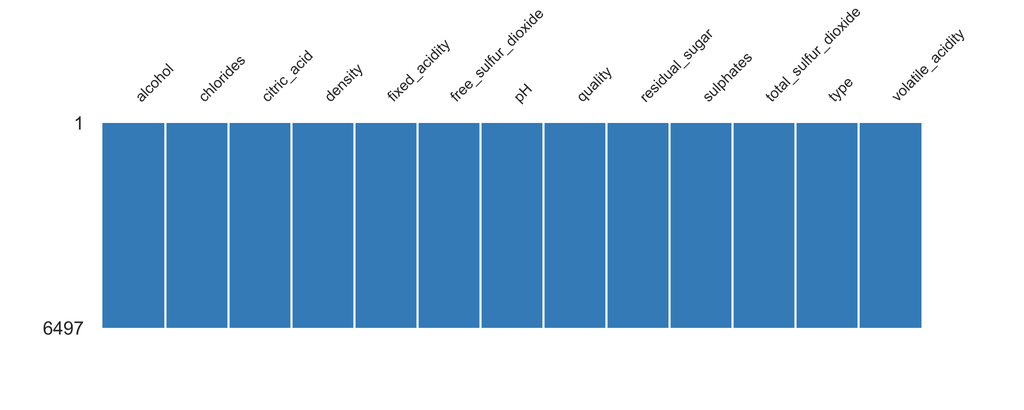

# Sample

## First rows

|  | alcohol | chlorides | citric_acid | density | fixed_acidity | free_sulfur_dioxide | pH | quality | residual_sugar | sulphates | total_sulfur_dioxide | type | volatile_acidity |
| --- | --- | --- | --- | --- | --- | --- | --- | --- | --- | --- | --- | --- | --- |
| 0 | 8.8 | 0.045 | 0.36 | 1.0010 | 7.0 | 45.0 | 3.00 | 6 | 20.7 | 0.45 | 170.0 | White | 0.27 |
| 1 | 9.5 | 0.049 | 0.34 | 0.9940 | 6.3 | 14.0 | 3.30 | 6 | 1.6 | 0.49 | 132.0 | White | 0.30 |
| 2 | 10.1 | 0.050 | 0.40 | 0.9951 | 8.1 | 30.0 | 3.26 | 6 | 6.9 | 0.44 | 97.0 | White | 0.28 |
| 3 | 9.9 | 0.058 | 0.32 | 0.9956 | 7.2 | 47.0 | 3.19 | 6 | 8.5 | 0.40 | 186.0 | White | 0.23 |
| 4 | 9.9 | 0.058 | 0.32 | 0.9956 | 7.2 | 47.0 | 3.19 | 6 | 8.5 | 0.40 | 186.0 | White | 0.23 |
| 5 | 10.1 | 0.050 | 0.40 | 0.9951 | 8.1 | 30.0 | 3.26 | 6 | 6.9 | 0.44 | 97.0 | White | 0.28 |
| 6 | 9.6 | 0.045 | 0.16 | 0.9949 | 6.2 | 30.0 | 3.18 | 6 | 7.0 | 0.47 | 136.0 | White | 0.32 |
| 7 | 8.8 | 0.045 | 0.36 | 1.0010 | 7.0 | 45.0 | 3.00 | 6 | 20.7 | 0.45 | 170.0 | White | 0.27 |
| 8 | 9.5 | 0.049 | 0.34 | 0.9940 | 6.3 | 14.0 | 3.30 | 6 | 1.6 | 0.49 | 132.0 | White | 0.30 |
| 9 | 11.0 | 0.044 | 0.43 | 0.9938 | 8.1 | 28.0 | 3.22 | 6 | 1.5 | 0.45 | 129.0 | White | 0.22 |

## Last rows

|  | alcohol | chlorides | citric_acid | density | fixed_acidity | free_sulfur_dioxide | pH | quality | residual_sugar | sulphates | total_sulfur_dioxide | type | volatile_acidity |
| --- | --- | --- | --- | --- | --- | --- | --- | --- | --- | --- | --- | --- | --- |
| 6487 | 9.2 | 0.073 | 0.20 | 0.99770 | 6.6 | 29.0 | 3.29 | 5 | 7.8 | 0.54 | 79.0 | Red | 0.725 |
| 6488 | 11.6 | 0.077 | 0.15 | 0.99314 | 6.3 | 26.0 | 3.32 | 6 | 1.8 | 0.82 | 35.0 | Red | 0.550 |
| 6489 | 11.6 | 0.089 | 0.09 | 0.99402 | 5.4 | 16.0 | 3.67 | 6 | 1.7 | 0.56 | 26.0 | Red | 0.740 |
| 6490 | 11.0 | 0.076 | 0.13 | 0.99574 | 6.3 | 29.0 | 3.42 | 6 | 2.3 | 0.75 | 40.0 | Red | 0.510 |
| 6491 | 9.5 | 0.068 | 0.08 | 0.99651 | 6.8 | 28.0 | 3.42 | 6 | 1.9 | 0.82 | 38.0 | Red | 0.620 |
| 6492 | 10.5 | 0.090 | 0.08 | 0.99490 | 6.2 | 32.0 | 3.45 | 5 | 2.0 | 0.58 | 44.0 | Red | 0.600 |
| 6493 | 11.2 | 0.062 | 0.10 | 0.99512 | 5.9 | 39.0 | 3.52 | 6 | 2.2 | 0.76 | 51.0 | Red | 0.550 |
| 6494 | 11.0 | 0.076 | 0.13 | 0.99574 | 6.3 | 29.0 | 3.42 | 6 | 2.3 | 0.75 | 40.0 | Red | 0.510 |
| 6495 | 10.2 | 0.075 | 0.12 | 0.99547 | 5.9 | 32.0 | 3.57 | 5 | 2.0 | 0.71 | 44.0 | Red | 0.645 |
| 6496 | 11.0 | 0.067 | 0.47 | 0.99549 | 6.0 | 18.0 | 3.39 | 6 | 3.6 | 0.66 | 42.0 | Red | 0.310 |